# Create MB SHH methylation UMAP

Ryan Corbett

2024

Load libraries and set directory paths

```r
suppressPackageStartupMessages({
  library(tidyverse)
  library(umap)
  library(ggplot2)
  library(devtools)
  library(gdata)
  library(ggpubr)
})

root_dir <- rprojroot::find_root(rprojroot::has_dir(".git"))

data_dir <- file.path(root_dir, "data")
analysis_dir <- file.path(root_dir, "analyses", "molecular-subtyping-MB")
results_dir <- file.path(analysis_dir, "results")
input_dir <- file.path(analysis_dir, "input")
plots_dir <- file.path(analysis_dir, "plot")
```

Set file paths

```r
hist_file <- file.path(data_dir, "histologies.tsv")
methyl_file <- file.path(data_dir, "v14", "methyl-beta-values.rds")
mb_shh_file <- file.path(results_dir, "mb_shh_subtypes_w_molecular_data.tsv")
```

Wrangle data. We will remove sample IDs from `mb_shh_subtypes` for which a high confidence methylation call indicates a non-MB tumor (to be further pathologically reviewed).

```r
hist <- read_tsv(hist_file)
mb_shh_subtypes <- read_tsv(mb_shh_file) %>%
  dplyr::filter(!sample_id %in% c("7316-1884", "7316-1676",
                     "7316-1666", "7316-3202"))
```

Filter hist for mb shh methyl samples, and append to subtype df

```r
hist_mb_methyl <- hist %>%
  dplyr::filter(pathology_diagnosis == "Medulloblastoma",
                experimental_strategy == "Methylation") %>%
  dplyr::rename(Kids_First_Biospecimen_ID_methyl = Kids_First_Biospecimen_ID)

mb_shh_subtypes <- mb_shh_subtypes %>%
  left_join(hist_mb_methyl %>%
              dplyr::select(match_id, Kids_First_Biospecimen_ID_methyl)) %>%
  dplyr::filter(!is.na(Kids_First_Biospecimen_ID_methyl)) %>%
  distinct(match_id, Kids_First_Biospecimen_ID_methyl, .keep_all = TRUE) %>%
  # redefine un-subtyped samples as "unk"
  dplyr::mutate(molecular_subtype = case_when(
    molecular_subtype == "MB, SHH" ~ "MB, SHH unk",
    TRUE ~ molecular_subtype
  )) %>%
  dplyr::mutate(molecular_subtype = fct_relevel(molecular_subtype,
                                               c("MB, SHH alpha", "MB, SHH beta",
                                                 "MB, SHH gamma", "MB, SHH delta",
                                                 "MB, SHH unk")))
```

Get number of samples by MB SHH subtype

```r
table(mb_shh_subtypes$SHH_subtype)
```

```
##
## SHH_alpha  SHH_beta SHH_delta SHH_gamma
##         8        13        12        12
```

Load methylation data and filter for ids in `mb_shh_subtypes`

```r
methyl <- readRDS(methyl_file)

mb_methyl <- methyl[,colnames(methyl) %in% c("Probe_ID", hist_mb_methyl$Kids_First_Biospecimen_ID_methyl)]

mb_methyl <- mb_methyl %>%
  distinct(Probe_ID, .keep_all = TRUE) %>%
  column_to_rownames("Probe_ID")
```

Identify 20k most variable probes among MB samples

```r
mb_methyl_var <- apply(mb_methyl, 1, var, na.rm = TRUE)

mb_var_probes <- names(sort(mb_methyl_var, decreasing = TRUE)[1:20000])
```

Generate UMAP results

```r
set.seed(2024)

mb_umap_results <- umap::umap(t(mb_methyl[mb_var_probes, ]))
mb_umap_plot_df <- data.frame(mb_umap_results$layout) %>%
  tibble::rownames_to_column("Kids_First_Biospecimen_ID_methyl") %>%
  left_join(hist_mb_methyl)
```

```r
umap_mb <-  ggplot(mb_umap_plot_df, aes(x = X1,
             y = X2,
             color = molecular_subtype)) +
  geom_point(alpha = 0.7) +
  labs(color = "molecular subtype") +
  theme_bw() +
  xlab("UMAP1") +
  ylab("UMAP2")

ggsave(file.path(plots_dir, "umap_mb.pdf"),
       umap_mb,
       width = 5.5, height = 3.5)
```

Identify 20k most variable probes among MB Group 3/4 samples

```r
g34_samples <- hist_mb_methyl %>%
  dplyr::filter(molecular_subtype %in% c("MB, Group3", "MB, Group4")) %>%
  pull(Kids_First_Biospecimen_ID_methyl)

mb_g34_methyl_var <- apply(mb_methyl[,colnames(mb_methyl) %in% g34_samples], 1, var, na.rm = TRUE)

mb_g34_var_probes <- names(sort(mb_g34_methyl_var, decreasing = TRUE)[1:20000])
```

Generate UMAP results

```r
mb_g34_umap_results <- umap::umap(t(mb_methyl[mb_g34_var_probes, colnames(mb_methyl) %in% g34_samples]))
mb_g34_umap_plot_df <- data.frame(mb_g34_umap_results$layout) %>%
  tibble::rownames_to_column("Kids_First_Biospecimen_ID_methyl") %>%
  left_join(hist_mb_methyl)
```

Plot UMAP with molecular subtype and methylation subtype

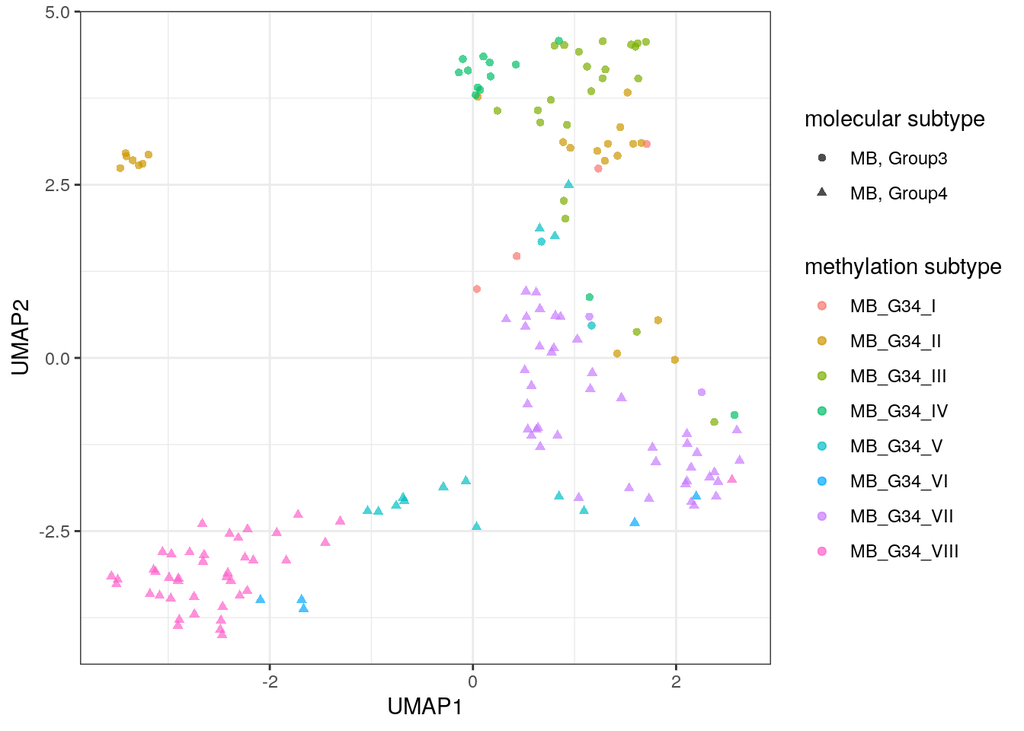

```r
mb_g34_umap_plot_df %>%
  dplyr::filter(grepl("MB_G34", dkfz_v12_methylation_subclass))  %>%
  ggplot(aes(x = X1,
             y = X2,
             color = dkfz_v12_methylation_subclass,
             shape = molecular_subtype)) +
  geom_point(alpha = 0.7) +
  labs(color = "methylation subtype",
       shape = "molecular subtype") +
  theme_bw() +
  xlab("UMAP1") +
  ylab("UMAP2")
```

```r
ggsave(file.path(plots_dir, "umap_mb_group34.pdf"),
       width = 5.5, height = 3.5)
```

Identify 20k most variable probes among MB SHH samples

```r
mb_shh_methyl_var <- apply(mb_methyl[,colnames(mb_methyl) %in% mb_shh_subtypes$Kids_First_Biospecimen_ID_methyl], 1, var, na.rm = TRUE)

mb_shh_var_probes <- names(sort(mb_shh_methyl_var, decreasing = TRUE)[1:20000])
```

Generate UMAP df

```r
mb_shh_umap_results <- umap::umap(t(mb_methyl[mb_shh_var_probes, colnames(mb_methyl) %in% mb_shh_subtypes$Kids_First_Biospecimen_ID_methyl]))
mb_shh_umap_plot_df <- data.frame(mb_shh_umap_results$layout) %>%
  tibble::rownames_to_column("Kids_First_Biospecimen_ID_methyl") %>%
  inner_join(mb_shh_subtypes)
mb_shh_umap_plot_df <- mb_shh_umap_plot_df %>%
  dplyr::mutate(age_range = case_when(
    age_at_diagnosis_years < 5 ~ "(0,5)",
    age_at_diagnosis_years < 10 ~ "[5,10)",
    age_at_diagnosis_years < 15 ~ "[10,15)",
    TRUE ~ ">=15"
  )) %>%
  dplyr::mutate(age_range = fct_relevel(age_range,
                                        c("(0,5)", "[5,10)",
                                          "[10,15)", ">=15"))) %>%
  dplyr::mutate(consensus_CN_MYCN = case_when(
    is.na(consensus_CN_MYCN) ~ "neutral",
    TRUE ~ consensus_CN_MYCN
  )) %>%
    dplyr::mutate(consensus_CN_GLI2 = case_when(
    is.na(consensus_CN_GLI2) ~ "neutral",
    TRUE ~ consensus_CN_GLI2
  )) %>%
    dplyr::mutate(consensus_CN_CCND2 = case_when(
    is.na(consensus_CN_CCND2) ~ "neutral",
    TRUE ~ consensus_CN_CCND2
  )) %>%
    dplyr::mutate(consensus_CN_PTEN = case_when(
    is.na(consensus_CN_PTEN) ~ "neutral",
    TRUE ~ consensus_CN_PTEN
  )) %>%
  dplyr::mutate(classification_source = case_when(
    classification_source == "Genomic/Expression" ~ "Molecular",
    is.na(classification_source) ~ "Unavailable",
    TRUE ~ classification_source
  )) %>%
  write_tsv(file.path(results_dir, "mb_shh_subtypes_w_molecular_umap_data.tsv"))
```

Plot UMAP with molecular subtype, classification source, and age range

```r
umap_mb_shh <-  ggplot(mb_shh_umap_plot_df, aes(x = X1,
             y = X2,
             color = molecular_subtype,
             size = age_range,
             shape = classification_source)) +
  geom_point(alpha = 0.7) +
  labs(color = "SHH subgroup",
       size = "age range (years)",
       shape = "classifcation source") +
  theme_bw() +
  xlab("UMAP1") +
  ylab("UMAP2") +
  # colors to match subtypes in Garcia-Lopez 2020 review
  scale_color_manual(values = c("aquamarine3", "goldenrod2",
                                "royalblue1", "plum4",
                                "gray")) +
  guides(color = guide_legend(order = 1),
         shape  = guide_legend(order = 2),
         size  = guide_legend(order = 3))

ggsave(file.path(plots_dir, "umap_mb_shh.pdf"),
       umap_mb_shh,
       width = 6.5, height = 4.5)
```

Plot UMAP with methylation subtype and methylation score

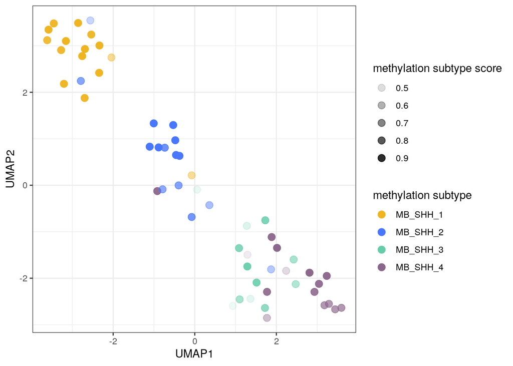

```r
mb_shh_umap_plot_df %>%
  dplyr::filter(grepl("MB", dkfz_v12_methylation_subclass_collapsed)) %>%

  ggplot(aes(x = X1,
             y = X2,
             color = dkfz_v12_methylation_subclass_collapsed,
             alpha = dkfz_v12_methylation_subclass_score_mean)) +
  geom_point(size = 3) +
  labs(color = "methylation subtype",
       alpha = "methylation subtype score") +
  theme_bw() +
  xlab("UMAP1") +
  ylab("UMAP2") +
  # colors to match subtypes in Garcia-Lopez 2020 review
  scale_color_manual(values = c("goldenrod2", "royalblue1",
                                "aquamarine3", "plum4"))
```

```r
ggsave(file.path(plots_dir, "umap_mb_shh_methylation_subtype.pdf"),
       width = 5.5, height = 3.5)
```

Plot UMAP with CN status for MYCN, GLI2, CCND2, and PTEN

```r
umap_plot_cn_df <- mb_shh_umap_plot_df %>%
  dplyr::select(molecular_subtype, X1, X2,
                consensus_CN_MYCN,
                consensus_CN_GLI2,
                consensus_CN_CCND2,
                consensus_CN_PTEN) %>%
  dplyr::rename(MYCN = consensus_CN_MYCN,
                GLI2 = consensus_CN_GLI2,
                CCND2 = consensus_CN_CCND2,
                PTEN = consensus_CN_PTEN) %>%
  gather(key = "gene_name", value = "CN_status",
         -molecular_subtype, -X1, -X2)

umap_mb_shh_cn <- ggplot(umap_plot_cn_df, aes(x = X1,
             y = X2,
             color = molecular_subtype,
             shape = CN_status)) +
  geom_point(alpha = 0.7, size = 3) +
  labs(color = "SHH subgroup",
       shape = "CN status") +
  facet_wrap(~gene_name, nrow = 2) +
  theme_bw() +
  xlab("UMAP1") +
  ylab("UMAP2") +
  # colors to match subtypes in Garcia-Lopez 2020 review
  scale_color_manual(values = c("aquamarine3", "goldenrod2",
                                "royalblue1", "plum4",
                                "gray"))

ggsave(file.path(plots_dir, "umap_mb_shh_cn_status.pdf"),
       umap_mb_shh_cn,
       width = 8, height = 5.5)
```

Plot UMAP with TP53 alteration status

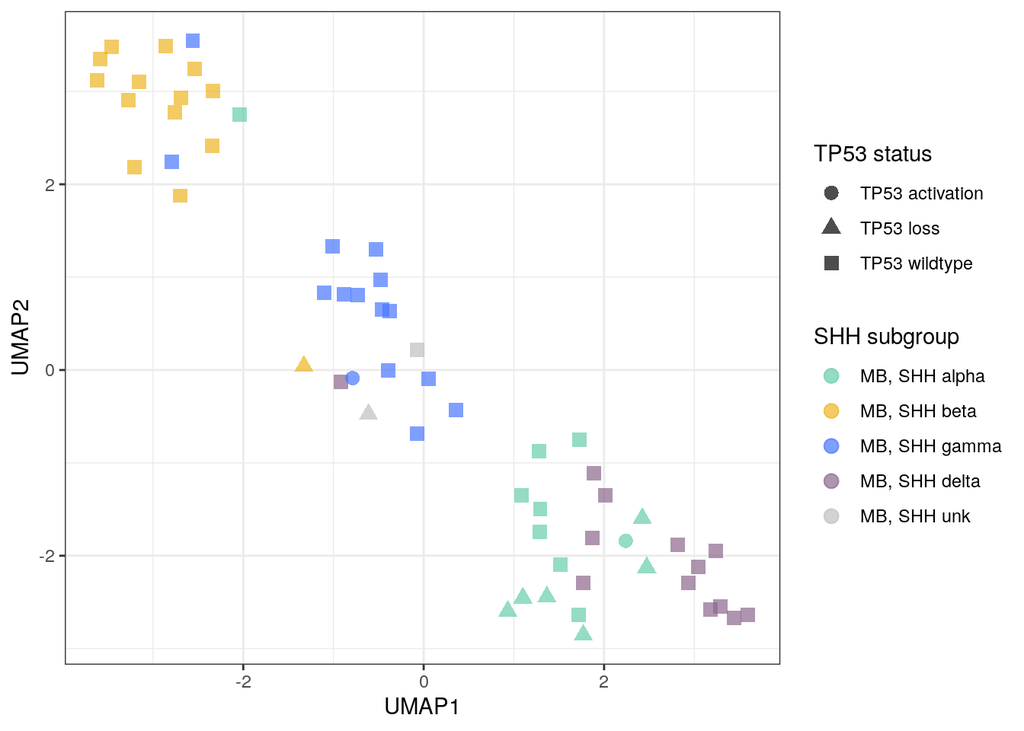

```r
mb_shh_umap_plot_df %>%
  ggplot(aes(x = X1,
             y = X2,
             color = molecular_subtype,
             shape = tp53_status)) +
  geom_point(alpha = 0.7, size = 3) +
  labs(color = "SHH subgroup",
       shape = "TP53 status") +
  theme_bw() +
  xlab("UMAP1") +
  ylab("UMAP2") +
  # colors to match subtypes in Garcia-Lopez 2020 review
  scale_color_manual(values = c("aquamarine3", "goldenrod2",
                                "royalblue1", "plum4",
                                "gray"))
```

```r
ggsave(file.path(plots_dir, "umap_mb_shh_tp53_status.pdf"),
       width = 5.5, height = 3.5)
```

Merge MB, MB SHH, and MB SHH + CN UMAPs into single figure and save

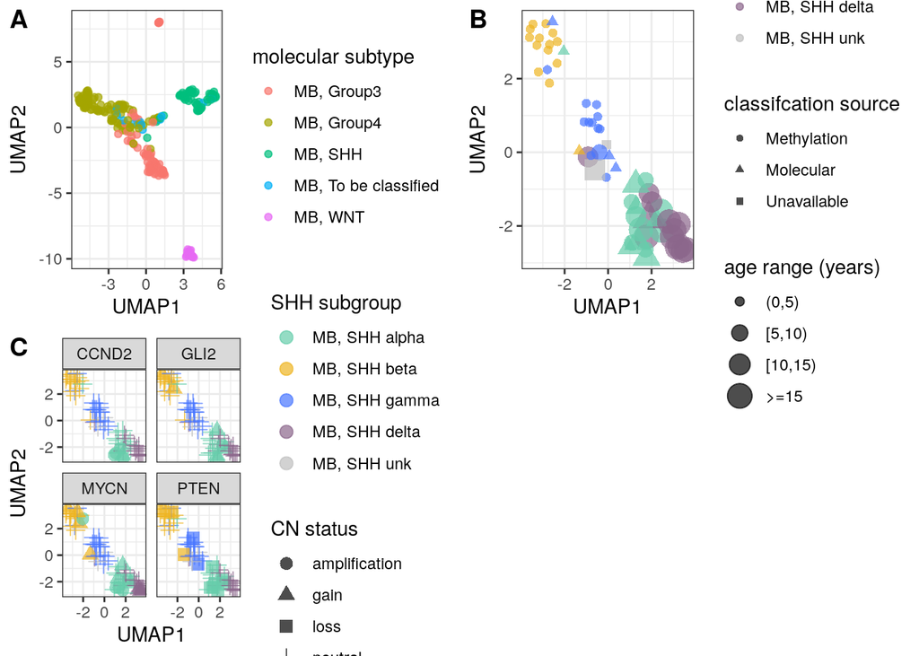

```r
merged_plot <- ggarrange(umap_mb,
                         umap_mb_shh,
                         umap_mb_shh_cn,
                         ncol = 2, nrow = 2,
                         labels = c("A", "B", "C"))
merged_plot
```

```r
ggsave(file.path(root_dir, "figures", "manuscript_OPC",
                 "figure3", "Figure3.png"),
    width = 13, height = 9)
```

Identify 20k most variable probes among MB WNT samples

```r
wnt_samples <- hist_mb_methyl %>%
  dplyr::filter(molecular_subtype %in% c("MB, WNT")) %>%
  pull(Kids_First_Biospecimen_ID_methyl)

mb_wnt_methyl_var <- apply(mb_methyl[,colnames(mb_methyl) %in% wnt_samples], 1, var, na.rm = TRUE)

mb_wnt_var_probes <- names(sort(mb_wnt_methyl_var, decreasing = TRUE)[1:20000])
```

Generate UMAP df

```r
set.seed(2024)

mb_wnt_umap_results <- umap::umap(t(mb_methyl[mb_wnt_var_probes, colnames(mb_methyl) %in% wnt_samples]))
mb_wnt_umap_plot_df <- data.frame(mb_wnt_umap_results$layout) %>%
  tibble::rownames_to_column("Kids_First_Biospecimen_ID_methyl") %>%
  left_join(hist_mb_methyl)
```

Plot UMAP with methylation subtype

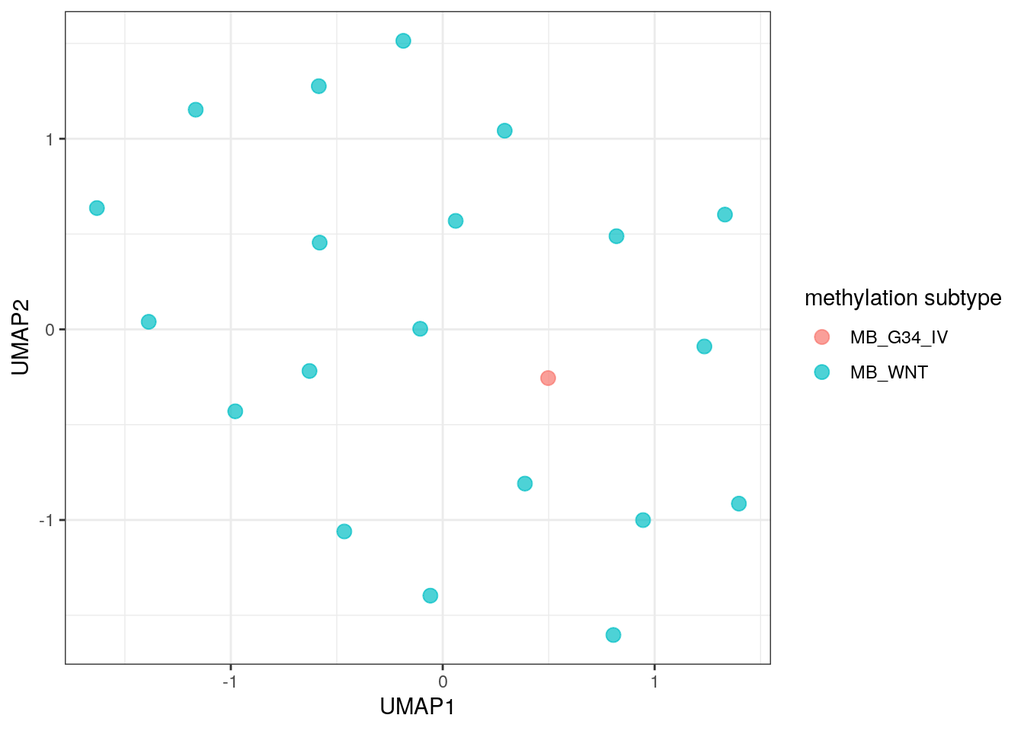

```r
mb_wnt_umap_plot_df %>%
  ggplot(aes(x = X1,
             y = X2,
             color = dkfz_v12_methylation_subclass)) +
  geom_point(alpha = 0.7, size = 3) +
  labs(color = "methylation subtype") +
  theme_bw() +
  xlab("UMAP1") +
  ylab("UMAP2")
```

```r
ggsave(file.path(plots_dir, "umap_mb_wnt.pdf"),
       width = 5.5, height = 3.5)
```